# Guia_3

f. El Teorema Central del Límite establece que la distribución de $$ \frac{\bar{X}_n- E(X_1)}{\sqrt{Var(\bar{X_n})}}= \frac{\bar{X}_n- E(X_1)}{\sqrt{ Var(X_1)/n}} \, $$ se aproxima a la distribución normal de la normal estándar, cuando $n$ es suficientemente grande.

Transforme los datos obtenidos en el item c) y estudie la distribución de cada conjunto de datos transformado mediante histogramas y boxplots.

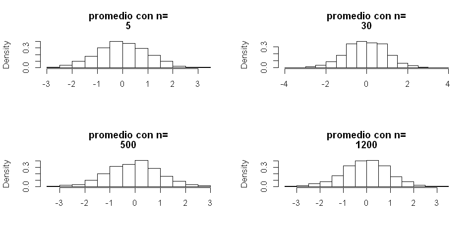

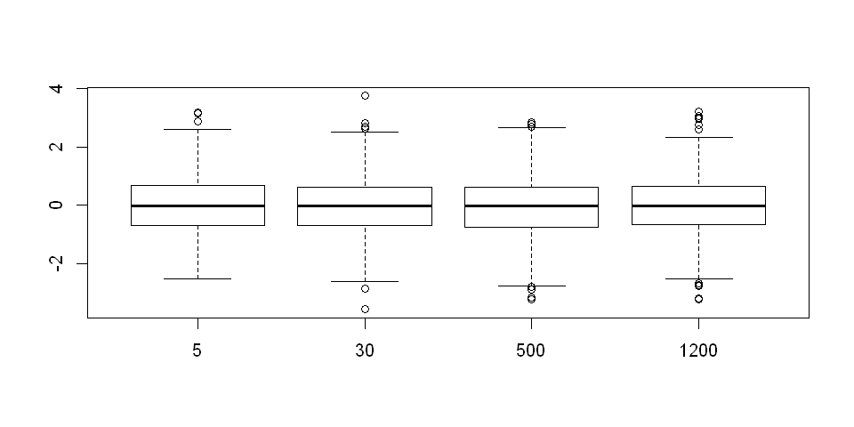

```r
## Hago todo de una sola vez.

enes<-c(5,30,500,1200)
largo_enes<-length(enes)
todo<-matrix(NA,Nrep*largo_enes,nrow=Nrep,ncol=largo_enes)
for (i in 1:largo_enes)
{
  ene=enes[i]
  matriz<-matrix(runif(Nrep*ene),nrow=Nrep, ncol=ene,byrow=T) #genero las Nrep=1000 unif del item anterior y otras Nrep
  xbarra<-apply(matriz,1,mean) #R oriented

##estandarizo con los valores verdaderos
  xbarra<-(xbarra-0.5)/sqrt(1/(12*ene))
  todo[,i]<-xbarra
  }


#hacemos un histograma por columna
par(mfrow=c(2,2))
for (j in 1:largo_enes)
{
  hist(todo[,j], freq=FALSE, main=c("promedio con n=",enes[j]),xlab=" ")
}
par(mfrow=c(1,1))

##Agrego un boxplot para visualizar
boxplot(todo,2,names=c("5","30","500","1200")) #hace un boxplot por columna
```

g. Repitamos el ítem e) generando ahora variables con distribución Cauchy $\mathcal C (0; 1)$. Recuerde de $\mathcal C (0; 1)$ coincide con Student con 1 grado de libertad (rt(n,df=1) es para generar en R). Comparemos los resultados obtenidos. ¿Se puede realizar el ítem f)? ¿Por qué?

```r
# Repetimos e) con la Cauchy

set.seed(123)
enes<-c(5,30,500,1200)
largo_enes<-length(enes)
todo<-matrix(NA,Nrep*largo_enes,nrow=Nrep,ncol=largo_enes)
for (i in 1:largo_enes)
{
  ene=enes[i]
  matriz<-matrix(rt(Nrep*ene,df=1),nrow=Nrep, ncol=ene,byrow=T) # genero las Nrep uniformes del item anterior y otras Nrep
  xbarra<-apply(matriz,1,mean) #R oriented
  todo[,i]<-xbarra
}

#vamos a calcular promedios y desvios por las columnas de todo
desvios.cauchy<-apply(todo,2,sd)    #desvio de cada columna
medias.cauchy<-apply(todo, 2, mean) #media de cada columna

desvios.cauchy
medias.cauchy
```

1. 69.4254816154896

2. 95.577323822584

3. 1606.16416388808

4. 12.3871093274609

1. 2.277207854246

2. -4.11878051063608

3. -50.910109213182

4. -0.562361341788221

3.Intervalos de Confianza: "Interval that contains an unknown quantity with a given frequency", All of Statistics, Wasserman.

a. Implemente una función intervalo.mu.asin que tenga por input el nivel $1-\alpha$ y un conjunto de datos $x_1,\ldots, x_n$, provenientes de una muestra de $X$, y devuelva el intervalo de confianza de nivel asintótico $1-\alpha$ para $\mu=\mathbb E(X)$.

```r
intervalo.mu.asin<- function(x,nivel)
{ media<- mean(x)
  desvio<-sd(x)
  n<- length(x)

  alfa2<- (1-nivel)/2
  zalfa2<- -qnorm(alfa2)
  liminf<-media-zalfa2*desvio/sqrt(n)
  limsup<-media+zalfa2*desvio/sqrt(n)

  list=c(liminf,limsup)
  return(list)
}
```

Nivel de Cubrimiento empírico: El nivel de cubrimiento empírico (de un procedimiento) se define como la proporción de veces que los intervalos (construidos con el procedimiento) utilizando datos simulados contiene a $\mu$ (o $\theta$), en cierta cantidad de $Nrep$ replicaciones.

b. Simulación bajo normalidad. Genere variables con distribucion normal de media $\mu=0$ y $\sigma=0.1, 1,10$. Calcule el cubrimiento empírico del intervalo de confianza asintótico de nivel 1-$\alpha$, definido en intervalo.mu.asin, para $\alpha=0.05$, $n=5$, $n=10$, $n=30$, $n=50$, $n=100$, $n=1000$, utilizando $Nrep=1000$ replicaciones, y complete la siguiente tabla. En cada caso, calcule el promedio de las longitudes en las $Nrep=1000$ replicaciones e incluya el valor en la tabla (long). Indique a que valor debe aproximarse el nivel de cubrimiento empírico. Comente los resultados obtenidos. En base a los resultados, ¿parece razonable este procedimiento para $n=5$? ¿Conoce algún procedimiento alternativo?

```r
set.seed(123)
enes<-c(5,10,30,50,100,1000)
Nrep<-1000
largo_enes<-length(enes)
sigmas<- c(0.1,1,10)
longitud<-cobertura<-matrix(0,nrow=length(sigmas),ncol=length(enes))

for (k in 1:length(sigmas)){
 sigma<-sigmas[k]
 for (i in 1:largo_enes)
 {
   ene=enes[i]
   matriz<-matrix(rnorm(Nrep*ene,0,sigma),nrow=Nrep, ncol=ene,byrow=T) # genero las Nrep normales
   ic<-apply(matriz,1,intervalo.mu.asin,nivel=0.95) #R oriented
   ic<-as.matrix(ic)
   longitud[k,i]<- mean(ic[2,]-ic[1,])
   cobertura[k,i]<- mean(ic[2,]*ic[1,]<0)
 }
}
colnames(cobertura)<- enes
rownames(cobertura)<-sigmas
cobertura

colnames(longitud)<- enes
rownames(longitud)<-sigmas
longitud
```

|  | 5 | 10 | 30 | 50 | 100 | 1000 |
| --- | --- | --- | --- | --- | --- | --- |
| 0.1 | 0.892 | 0.936 | 0.941 | 0.950 | 0.960 | 0.963 |
| 1 | 0.871 | 0.919 | 0.943 | 0.935 | 0.963 | 0.956 |
| 10 | 0.886 | 0.917 | 0.944 | 0.957 | 0.943 | 0.962 |

|  | 5 | 10 | 30 | 50 | 100 | 1000 |
| --- | --- | --- | --- | --- | --- | --- |
| 0.1 | 0.1644235 | 0.1210051 | 0.07106871 | 0.05525547 | 0.03923503 | 0.01238693 |
| 1 | 1.6456013 | 1.2041284 | 0.71163165 | 0.54984755 | 0.38927198 | 0.12401016 |
| 10 | 16.8083246 | 12.0333885 | 7.11837325 | 5.48462670 | 3.91333790 | 1.23938386 |

c. Algo de Bootstrap: Implemente una función intervalo.mediana.boot que tenga por input el nivel $1-\alpha$ y un conjunto de datos $x_1,\ldots, x_n$, provenientes de una muestra de $X$, y devuelva el intervalo de confianza asintótico $1-\alpha$ para la mediana de $X$. Para ello, asuma que la mediana muestral es asintóticamente normal y estime el desvío del estimador mediante remuestreo con $Nboot=100$.

```r
intervalo.mediana.boot<- function(x,nivel)
{
    Nboot<- 100
# Estimacion bootstrap del desvio de la mediana
# Remuestreo
   mediana_boot<-rep(NA,Nboot)
   for (i in 1:Nboot)
   {
       x_boot<-sample(x,length(x),replace=TRUE)
       mediana_boot[i]<-median(x_boot)
   }

#estimacion boot del desvio
  sd_mediana<-sd(mediana_boot)
  alfa2<- (1-nivel)/2
  zalfa2<- -qnorm(alfa2)

# Calculamos intervalo de confianza para la mediana de x
# usando  desvio del estimador estimado con bootstrap
lininf<-median(x)-zalfa2*sd_mediana
limsup<-median(x)+zalfa2*sd_mediana
intervalo<-c(lininf,limsup)
return(intervalo)
}
```

d. Simulación bajo Cauchy. Genere variables con distribucion Cauchy $\mathcal C (0,1)$.Calcule el cubrimiento empírico del intervalo de confianza bootstrap para la mediana, definido en intervalo.mediana.boot, para $\alpha=0.05$, $n=30$, $n=50$, $n=100$ y $n=1000$, utilizando $Nrep=1000$ replicaciones, y complete la siguiente tabla. En cada caso, calcule el promedio de las longitudes en las $Nrep=1000$ replicaciones y y el cubrimiento empírico. Indique a que valor debe aproximarse el nivel de cubrimiento empírico. Comente los resultados obtenidos.

```r
set.seed(123)
enes<-c(30,50,100,1000)
Nrep<-1000
largo_enes<-length(enes)
longitud<-cobertura<-rep(0,length=length(enes))

for (i in 1:largo_enes)
 {
   ene=enes[i]
   matriz<-matrix(rt(Nrep*ene,df=1),nrow=Nrep, ncol=ene,byrow=T) # genero las Nrep Cauchy
   ic<-apply(matriz,1,intervalo.mediana.boot,nivel=0.95) #R oriented
   ic<-as.matrix(ic)
   longitud[i]<- mean(ic[2,]-ic[1,])
   cobertura[i]<- mean(ic[2,]*ic[1,]<0)
 }

rbind(enes,cobertura)

rbind(enes,longitud)
```

| enes | 30.000 | 50.000 | 100.000 | 1000.000 |
| --- | --- | --- | --- | --- |
| cobertura | 0.958 | 0.938 | 0.947 | 0.931 |

| enes | 30.000000 | 50.0000000 | 100.0000000 | 1000.0000000 |
| --- | --- | --- | --- | --- |
| longitud | 1.294684 | 0.9370158 | 0.6443115 | 0.1952487 |